# ZhiLiu_HW3

Zhi Liu

September 18, 2016

### 4.3

1. $-0.0694$ is the coefficient associated with the decade, signifying with every 1 decade increase, the probability that the starting pitcher pitched a complete game drops 0.0694.
2. $\hat\pi(12) = 0.7578 - 0.0694 * 12 = -0.075$. Not plausible because probability cannot be negative.
3. $\hat\pi(12) = \frac{e^{1.148 - 0.315 * 12}}{1 + e^{1.148 - 0.315 * 12}} = 0.06710713$. More plausible because it is within range [0, 1].

### 4.5

1. Logistic regression:

```r
data <- data.frame(T = c(66, 70, 69, 68, 67, 72, 73, 70, 57, 63, 70, 78, 67, 53, 67, 75, 70, 81, 76, 79, 75, 76, 58), TD = c(0, 1, 0, 0, 0, 0, 0, 0, 1, 1, 1, 0, 0, 1, 0, 0, 0, 0, 0, 0,1, 0, 1))
m <- glm(TD ~ T, data = data, family = binomial(logit))
summary(m)
```

```
##
## Call:
## glm(formula = TD ~ T, family = binomial(logit), data = data)
##
## Deviance Residuals:
##     Min       1Q   Median       3Q      Max
## -1.0611  -0.7613  -0.3783   0.4524   2.2175
##
## Coefficients:
##             Estimate Std. Error z value Pr(>|z|)
## (Intercept)  15.0429     7.3786   2.039   0.0415 *
## T            -0.2322     0.1082  -2.145   0.0320 *
## ---
## Signif. codes:  0 '***' 0.001 '**' 0.01 '*' 0.05 '.' 0.1 ' ' 1
##
## (Dispersion parameter for binomial family taken to be 1)
##
##     Null deviance: 28.267  on 22  degrees of freedom
## Residual deviance: 20.315  on 21  degrees of freedom
## AIC: 24.315
##
## Number of Fisher Scoring iterations: 5
```

The coefficient associated with temperature is -0.2322, meaning with every Fahrenheit increase of temperature the log odds of at least one primary O-ring suffered from thermal distress drops 0.2322.

2. The probability of positive event:

```r
predict(m, newdata = data.frame(T = 31), type='response')
```

```
##         1
## 0.9996088
```

Very likely.

3. Find the root:

```r
f <- function(T) {
  logodds <- m$coefficients[['(Intercept)']] + T * m$coefficients[['T']]
  exp(logodds) / (1 + exp(logodds)) - 0.5
  }
T.root <- uniroot(f, c(30, 70))$root
T.root
```

```
## [1] 64.79464
```

The slope of the linear approximation can be given as:

```r
f <- function(T) {
  logodds <- m$coefficients[['(Intercept)']] + T * m$coefficients[['T']]
  exp(logodds) / (1 + exp(logodds))
  }

slope <- (f(T.root + 0.5) - f(T.root - 0.5))/1
slope
```

```
## [1] -0.0579756
```

4. With every Fahrenheit increase of temperature the odds of at least one primary O-ring suffered from thermal distress drops $1 - e^{-0.2322} = 0.2072125$ times the odds at that temperature point.
5. 1. The Wald test:

```r
library(aod)
wald.test(b = coef(m), Sigma = vcov(m), Terms=2)
```

```
## Wald test:
## ----------
##
## Chi-squared test:
## X2 = 4.6, df = 1, P(> X2) = 0.032
```

2. The likelihood-ratio test:

```r
pchisq(28.267 - 20.315, 1,lower.tail = FALSE)
```

```
## [1] 0.004803426
```

### 4.7

1. Perform logistic regression:

```r
data <- data.frame(age = c(12, 15, 42, 52, 59, 73, 82, 91, 96, 105, 114, 120, 121, 128, 130, 139, 139, 157, 1, 1, 2, 8, 11, 18, 22, 31, 37, 61, 72, 81, 97, 112, 118, 127, 131, 140, 151, 159, 177, 206), kyphosis = c(rep(1, 18), rep(0, 22)))
m1 <- glm(kyphosis ~ age, data = data, family = binomial(logit))
summary(m1)
```

```
##
## Call:
## glm(formula = kyphosis ~ age, family = binomial(logit), data = data)
##
## Deviance Residuals:
##     Min       1Q   Median       3Q      Max
## -1.3126  -1.0907  -0.9482   1.2170   1.4052
##
## Coefficients:
##              Estimate Std. Error z value Pr(>|z|)
## (Intercept) -0.572693   0.602395  -0.951    0.342
## age          0.004296   0.005849   0.734    0.463
##
## (Dispersion parameter for binomial family taken to be 1)
##
##     Null deviance: 55.051  on 39  degrees of freedom
## Residual deviance: 54.504  on 38  degrees of freedom
## AIC: 58.504
##
## Number of Fisher Scoring iterations: 4
```

```r
pchisq(55.051 - 54.504, 1, lower.tail = FALSE)
```

```
## [1] 0.4595461
```

The p-value 0.4595461 is quite large. The effect of age is likely to be small.

2. Plot:

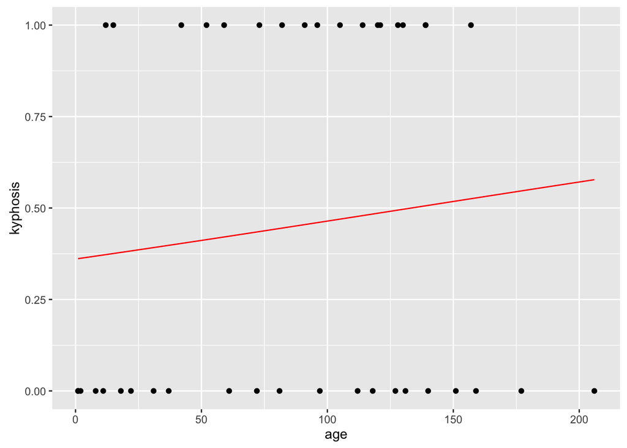

```r
library(ggplot2)
age.sorted <- seq(min(data$age), max(data$age), 1)
ggplot(data = data, aes(x = age, y = kyphosis)) + geom_point() + geom_line(aes(x, y), data = data.frame(x = age.sorted, y = predict(m1, data.frame(age = age.sorted), type='response')), col='red')
```

The distribution of the two kyphosis levels:

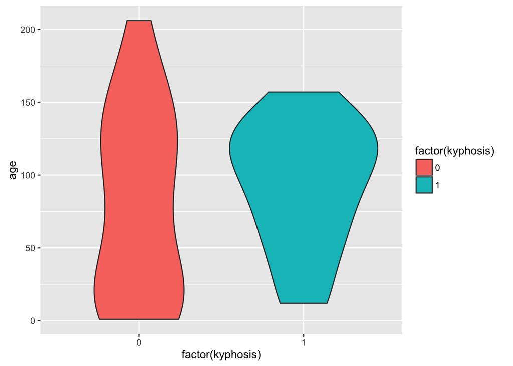

```r
ggplot(data = data, aes(x = factor(kyphosis), y = age, fill = factor(kyphosis))) + geom_violin()
```

They do not have normal distributions.

3. Logistic regression with age$^2$ term:

```r
m2 <- glm(kyphosis ~ age + I(age^2), data = data, family = binomial(logit))
summary(m2)
```

```
##
## Call:
## glm(formula = kyphosis ~ age + I(age^2), family = binomial(logit),
##     data = data)
##
## Deviance Residuals:
##    Min      1Q  Median      3Q     Max
## -1.482  -1.009  -0.507   1.012   1.788
##
## Coefficients:
##               Estimate Std. Error z value Pr(>|z|)
## (Intercept) -2.0462547  0.9943478  -2.058   0.0396 *
## age          0.0600398  0.0267808   2.242   0.0250 *
## I(age^2)    -0.0003279  0.0001564  -2.097   0.0360 *
## ---
## Signif. codes:  0 '***' 0.001 '**' 0.01 '*' 0.05 '.' 0.1 ' ' 1
##
## (Dispersion parameter for binomial family taken to be 1)
##
##     Null deviance: 55.051  on 39  degrees of freedom
## Residual deviance: 48.228  on 37  degrees of freedom
## AIC: 54.228
##
## Number of Fisher Scoring iterations: 4
```

```r
anova(m1, m2)
```

```
## Analysis of Deviance Table
##
## Model 1: kyphosis ~ age
## Model 2: kyphosis ~ age + I(age^2)
##   Resid. Df Resid. Dev Df Deviance
## 1        38     54.504
## 2        37     48.228  1   6.2762
```

```r
pchisq(6.2762, 1, lower.tail = FALSE)
```

```
## [1] 0.01223702
```

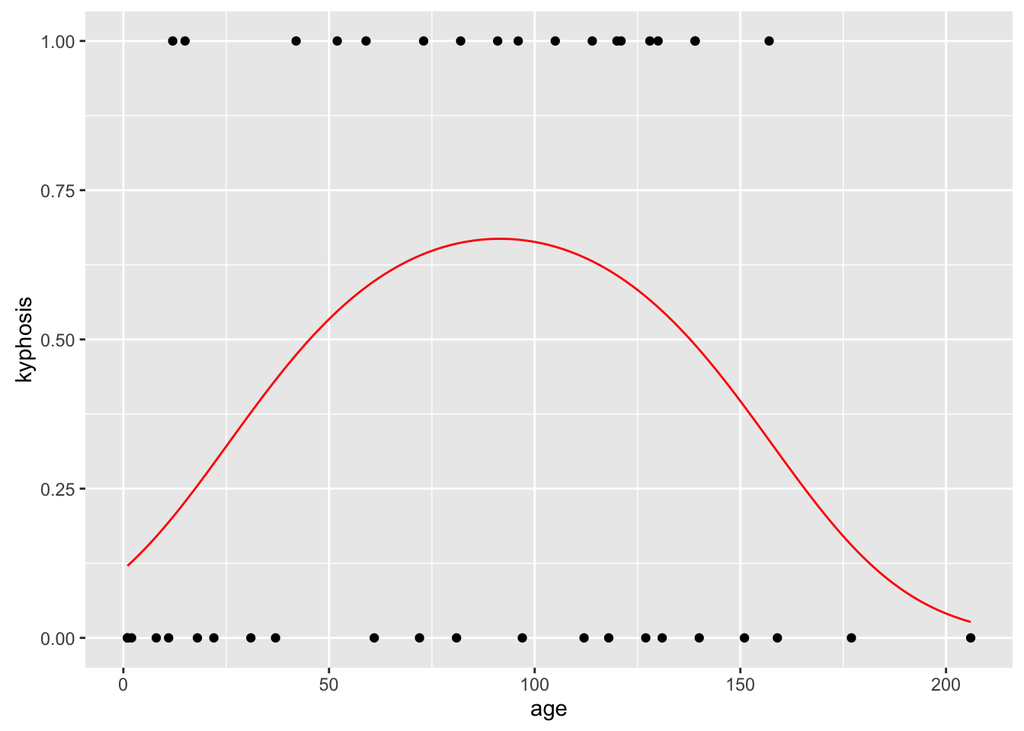

```r
ggplot(data = data, aes(x = age, y = kyphosis)) + geom_point() + geom_line(aes(x, y), data = data.frame(x = age.sorted, y = predict(m2, data.frame(age = age.sorted), type='response')), col='red')
```

The squared age term makes the curve non-monotone.

### 4.15

1. CMH test:

```r
data <-
array(c(24, 47, 9, 12,
        10, 45, 3, 8,
        5, 57, 4, 9,
        16, 54, 7, 10,
        7, 59, 4, 12),
      dim = c(2, 2, 5),
      dimnames = list(
          race = c("black", "white"),
          merit.pay = c("yes", "no"),
          district = c("NC", "NE", "NW", "SE", "SW")))
mantelhaen.test(data)
```

```
##
##  Mantel-Haenszel chi-squared test with continuity correction
##
## data:  data
## Mantel-Haenszel X-squared = 6.9797, df = 1, p-value = 0.008244
## alternative hypothesis: true common odds ratio is not equal to 1
## 95 percent confidence interval:
##  0.2652676 0.8036854
## sample estimates:
## common odds ratio
##         0.4617269
```

The p-value 0.008244 is small, signifying that at least in one district the $OR$ of getting the merit pay between races. The common $OR_{bw}$ 0.4617269 means blacks in general get less merit pay than whites.

2. Logistic regression:

```r
data.ftable <- ftable(data, row.vars = c('district', 'race'))
response <- cbind(yes = data.ftable[1:10], no = data.ftable[11:20])
district <- factor(rep(c("NC", "NE", "NW", "SE", "SW"), each = 2))
race <- factor(rep(c("black", "white"), 5))
```

Simply treating race as an explanatory variable leads to:

```r
m1 <- glm(response ~ race, family = binomial(logit))
summary(m1)
```

```
##
## Call:
## glm(formula = response ~ race, family = binomial(logit))
##
## Deviance Residuals:
##      Min        1Q    Median        3Q       Max
## -0.89000  -0.35517   0.06776   0.34982   0.59845
##
## Coefficients:
##             Estimate Std. Error z value Pr(>|z|)
## (Intercept)   0.8313     0.2306   3.605 0.000312 ***
## racewhite     0.8052     0.2768   2.910 0.003619 **
## ---
## Signif. codes:  0 '***' 0.001 '**' 0.01 '*' 0.05 '.' 0.1 ' ' 1
##
## (Dispersion parameter for binomial family taken to be 1)
##
##     Null deviance: 10.6649  on 9  degrees of freedom
## Residual deviance:  2.5876  on 8  degrees of freedom
## AIC: 41.953
##
## Number of Fisher Scoring iterations: 4
```

Looking at the residual deviance 2.5876, this is already good. Race has a big effect. $\log OR_{wb} = 0.8052$, $OR_{bw} = 0.4469985$.

3. With CHM test, we can only know if all $OR = 1$ or at least one $OR \neq 1$. Additional steps need to be done to get the direction. In addition, all directions should be the same for CHM to work.

On the other hand, a model-based analysis can be flexible about directions of different levels, by adding the categorical variable district to fit the data better:

```r
m2 <- glm(response ~ district + race, family = binomial(logit))
summary(m2)
```

```
##
## Call:
## glm(formula = response ~ district + race, family = binomial(logit))
##
## Deviance Residuals:
##        1         2         3         4         5         6         7
##  0.60191  -0.53319   0.30311  -0.18583  -0.97042   0.47422  -0.09608
##        8         9        10
##  0.07216  -0.30707   0.15054
##
## Coefficients:
##             Estimate Std. Error z value Pr(>|z|)
## (Intercept)  0.74947    0.29581   2.534  0.01129 *
## districtNE   0.25837    0.42067   0.614  0.53909
## districtNW   0.13836    0.40517   0.341  0.73273
## districtSE   0.12087    0.37287   0.324  0.74581
## districtSW   0.00445    0.38486   0.012  0.99077
## racewhite    0.79129    0.28532   2.773  0.00555 **
## ---
## Signif. codes:  0 '***' 0.001 '**' 0.01 '*' 0.05 '.' 0.1 ' ' 1
##
## (Dispersion parameter for binomial family taken to be 1)
##
##     Null deviance: 10.665  on 9  degrees of freedom
## Residual deviance:  2.071  on 4  degrees of freedom
## AIC: 49.437
##
## Number of Fisher Scoring iterations: 4
```

Residual deviance is further reduced from 2.5876 to 2.071. This variable does not have an effect as large as race.

### 4.19

1. Because this model does not have interacting terms, the $OR$ between different levels of a variable are the same. $OR_{fm} = e^{\hat{\beta}_1^G} = e^{0.16} = 1.173511$. Females are more likely to be in foavor of legalizing abortion.

$$\log Odds(Male, Catholic, Republican) = \hat{\alpha} + \hat{\beta}_2^R + \hat{\beta}_2^P = -0.11 - 0.66 - 1.67 = -2.44 \\
\hat{\pi}(Male, Catholic, Republican) = \frac{e^{-2.44}}{1 + e^{-2.44}} = 0.08017291$$

$$\log Odds(Female, Jewish, Democrat) = \hat{\alpha} + \hat{\beta}_1^G + \hat{\beta}_1^P = -0.11 + 0.16 + 0.84 = 0.89 \\
\hat{\pi}(Female, Jewish, Democrat) = \frac{e^{0.89}}{1 + e^{0.89}} = 0.7088902$$

3. $\hat{\beta}_2^G = -0.16$. In turn, $OR_{fm} = e^{-\hat{\beta}_2^G} = e^{0.16} = 1.173511$.
4. Setting the sum to be 0 means $\hat{\alpha}$ is the average likelihood. Considering gender alone, the average likelihood is $(2\alpha + \hat{\beta}_1^G) = (-0.11 * 2 + 0.16)/2 = -0.03$. The parameters under the new constraints should yield the same $\log Odds$ for all levels. Therefore

$$\hat{\beta'}_1^G = \hat{\alpha} + \hat{\beta}_1^G - \hat{\alpha'} = -0.11 + 0.16 - (-0.03) = 0.08 \\
\hat{\beta'}_2^G = \hat{\alpha} - \hat{\alpha'} = -0.11 - (-0.03) = -0.08$$

One sees that the $\log OR_{fm} = \hat{\beta}_1^G - \hat{\beta}_2^G = \hat{\beta'}_1^G - \hat{\beta'}_2^G$ is not changed.

### 4.23

The generic prediction equation is

$$logit(\pi) = \alpha + \beta_A A + \beta_S S + \beta_R R + \beta_{RS} R*S$$

1. When $R = 1$,

$$logit(\pi) = -7.00 + 0.10 A + 1.20 S + 0.30 + 0.20 S = -6.70 + 0.10 A + 1.40 S \\
OR = e^{1.40} = 4.0552$$

When $R = 0$,

$$logit(\pi) = -7.00 + 0.10 A + 1.20 S \\
OR = e^{1.20} = 3.320117$$

When $S = 1$,

$$logit(\pi) = -7.00 + 0.10 A + 1.20 + 0.30 R + 0.20 R = -5.80 + 0.10 A + 0.50 R \\
OR = e^{0.5} = 1.648721$$

When $S = 0$,

$$logit(\pi) = -7.00 + 0.10 A + 0.30 R \\
OR = e^{0.30} = 1.349859$$

2. Coefficients of $R$ and $S$ stand for the change in $\log Odds$ while the value changes from 0 to 1, ignoring the interaction $R*S$ term. The p-values stand for the effects of these variables. If these values are small, the corresponding variables are influential.
3. New prediction equation:

$$logit(\pi) = \alpha + \beta_A A + \beta_S S + \beta_R R + \beta_{RS} R*S + \beta_{AR} A*R$$

When $R = 1$,

$$logit(\pi) = -6.70 + 0.10 A + 1.40 S + 0.04 A = -6.70 + 0.14 A + 1.40 S$$

When $R = 0$,

$$logit(\pi) = -7.00 + 0.10 A + 1.20 S$$

The fact that the $0.04 A$ term when $R = 1$ can be combined to the $0.10 A$ demonstrates that it represents the difference between the effect of $A$ for blacks and whites.

### 4.25

1. The new model with interactions would be:

$$logit(\pi) = \alpha + \beta_1 c_1 + \beta_2 c_2 + \beta_3 c_3 + \beta_4 x + \beta_{14} c_1 x + \beta_{24} c_2 x + \beta_{34} c_3 x$$

```r
data <- read.table('~/Documents/All Documents/Academics/Categorical Data Analysis/HWs_exams/hsc.dat', header = 1)
data$color <- factor(data$color)
m1 <- glm(y ~ color * width, data = data, family = binomial(logit))
summary(m1)
```

```
##
## Call:
## glm(formula = y ~ color * width, family = binomial(logit), data = data)
##
## Deviance Residuals:
##     Min       1Q   Median       3Q      Max
## -2.0546  -0.9130   0.5285   0.8140   1.9657
##
## Coefficients:
##               Estimate Std. Error z value Pr(>|z|)
## (Intercept)   -1.75261   11.46409  -0.153    0.878
## color3        -8.28735   12.00363  -0.690    0.490
## color4       -19.76545   13.34251  -1.481    0.139
## color5        -4.10122   13.27532  -0.309    0.757
## width          0.10600    0.42656   0.248    0.804
## color3:width   0.31287    0.44794   0.698    0.485
## color4:width   0.75237    0.50435   1.492    0.136
## color5:width   0.09443    0.50042   0.189    0.850
##
## (Dispersion parameter for binomial family taken to be 1)
##
##     Null deviance: 225.76  on 172  degrees of freedom
## Residual deviance: 183.08  on 165  degrees of freedom
## AIC: 199.08
##
## Number of Fisher Scoring iterations: 5
```

For color2: $logit(\pi) = -1.75261 + 0.10600 x$.

For color3: $logit(\pi) = -1.75261 - 8.28735 + 0.10600 x + 0.31287 x = -10.03996 + 0.41887 x$.

For color4: $logit(\pi) = -1.75261 - 19.76545 + 0.10600 x + 0.75237 x = -21.51806 + 0.85837 x$.

For color5: $logit(\pi) = -1.75261 - 4.10122 + 0.10600 x + 0.09443 x = -5.85383 + 0.20043 x$.

Plot $\log Odds$:

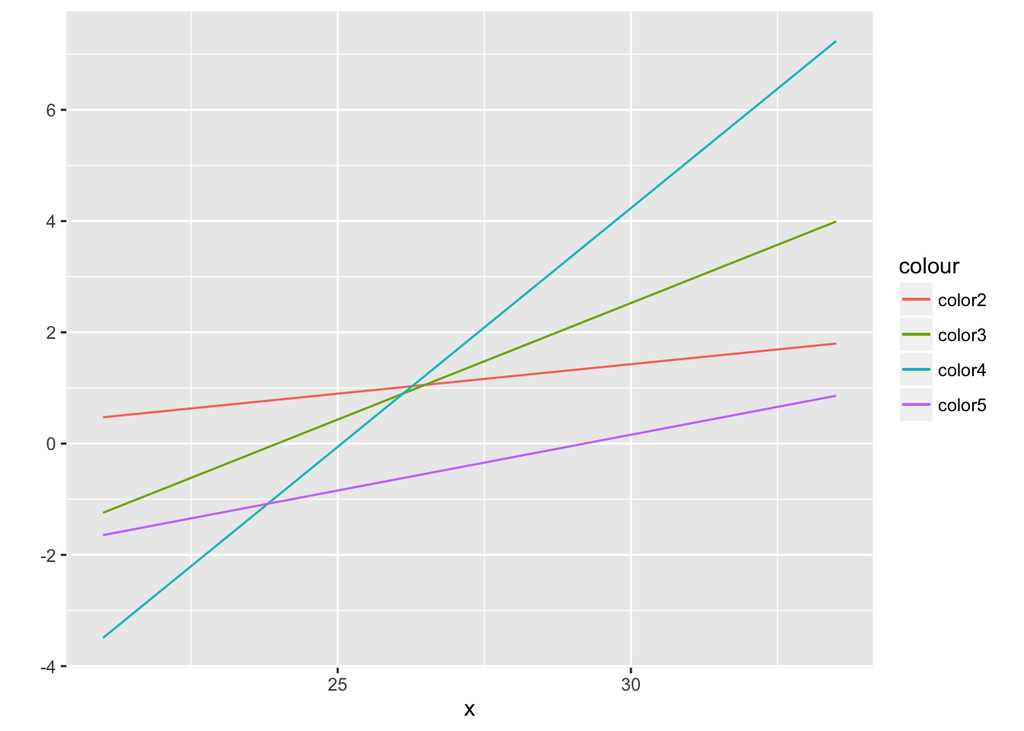

```r
x <- seq(min(data$width), max(data$width), 0.1)
color2 <- -1.75261 + 0.10600 * x
color3 <- -10.03996 + 0.41887 * x
color4 <- -21.51806 + 0.85837 * x
color5 <- -5.85383 + 0.20043 * x
ggplot(data = data.frame(x = x, color2 = color2, color3 = color3, color4 = color4, color5 = color5)) + geom_line(aes(x, color2, col='color2')) + geom_line(aes(x, color3, col='color3')) + geom_line(aes(x, color4, col='color4')) + geom_line(aes(x, color5, col='color5')) + ylab("")
```

Plot $\pi$:

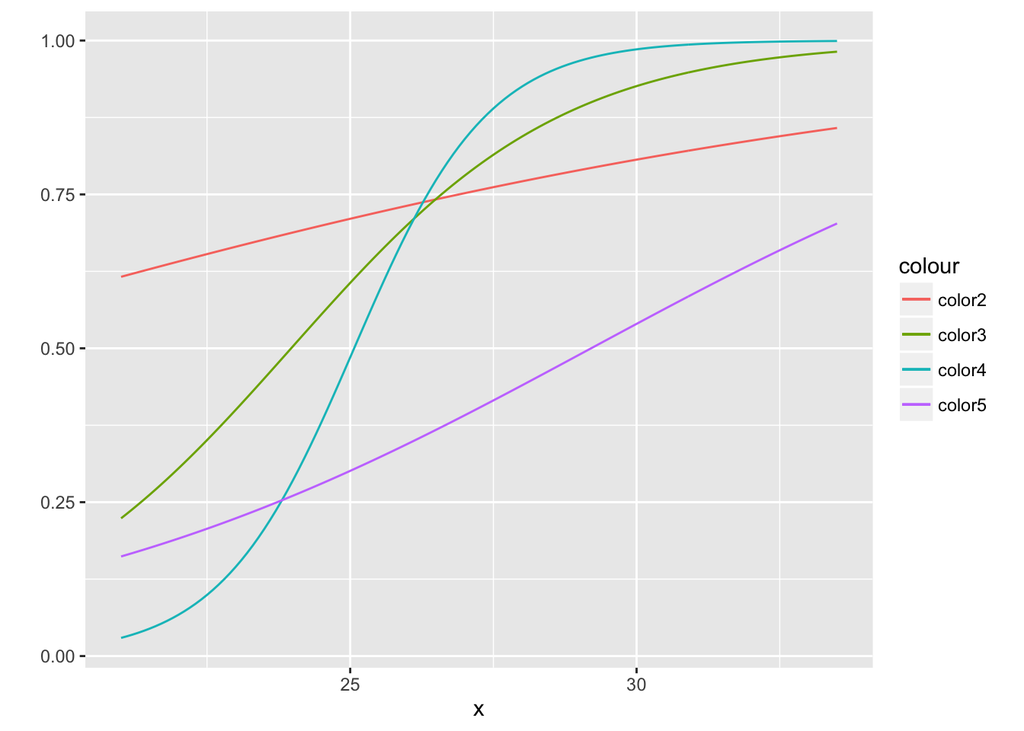

```r
get_pi <- function(log.odds) {
  exp(log.odds) / (1 + exp(log.odds))
}

ggplot(data = data.frame(x = x, color2 = get_pi(color2), color3 = get_pi(color3), color4 = get_pi(color4), color5 = get_pi(color5))) + geom_line(aes(x, color2, col='color2')) + geom_line(aes(x, color3, col='color3')) + geom_line(aes(x, color4, col='color4')) + geom_line(aes(x, color5, col='color5')) + ylab("")
```

In all levels, width is positively correlated with the probability of a satellite, although following different functional behaviors.

2. Simpler model:

```r
m2 <- glm(y ~ color + width, data = data, family = binomial(logit))
summary(m2)
```

```
##
## Call:
## glm(formula = y ~ color + width, family = binomial(logit), data = data)
##
## Deviance Residuals:
##     Min       1Q   Median       3Q      Max
## -2.1124  -0.9848   0.5243   0.8513   2.1413
##
## Coefficients:
##              Estimate Std. Error z value Pr(>|z|)
## (Intercept) -11.38519    2.87346  -3.962 7.43e-05 ***
## color3        0.07242    0.73989   0.098    0.922
## color4       -0.22380    0.77708  -0.288    0.773
## color5       -1.32992    0.85252  -1.560    0.119
## width         0.46796    0.10554   4.434 9.26e-06 ***
## ---
## Signif. codes:  0 '***' 0.001 '**' 0.01 '*' 0.05 '.' 0.1 ' ' 1
##
## (Dispersion parameter for binomial family taken to be 1)
##
##     Null deviance: 225.76  on 172  degrees of freedom
## Residual deviance: 187.46  on 168  degrees of freedom
## AIC: 197.46
##
## Number of Fisher Scoring iterations: 4
```

```r
anova(m2, m1)
```

```
## Analysis of Deviance Table
##
## Model 1: y ~ color + width
## Model 2: y ~ color * width
##   Resid. Df Resid. Dev Df Deviance
## 1       168     187.46
## 2       165     183.08  3   4.3764
```

```r
pchisq(4.3764, 3, lower.tail = FALSE)
```

```
## [1] 0.2235837
```

The p-value 0.2235837 is large. The interaction is not necessary.